# Exercise 3

hannajulku

# 3: Logistic regression

## Data set

Read the data from csv file to R and check it looks fine.

```r
#access libraries to be needed
library(boot)
library(readr)
library(tidyverse)
library(dplyr)
library(GGally)
```

```r
library(ggplot2)
library(finalfit)
# read the data into a data frame
alc <- read.csv(file = "\\\\ad.helsinki.fi/home/h/hkonstar/Desktop/IDOS/IODS-project/data/alc.csv")
# print variable names
names(alc)
```

```
##  [1] "school"     "sex"        "age"        "address"    "famsize"
##  [6] "Pstatus"    "Medu"       "Fedu"       "Mjob"       "Fjob"
## [11] "reason"     "guardian"   "traveltime" "studytime"  "schoolsup"
## [16] "famsup"     "activities" "nursery"    "higher"     "internet"
## [21] "romantic"   "famrel"     "freetime"   "goout"      "Dalc"
## [26] "Walc"       "health"     "failures"   "paid"       "absences"
## [31] "G1"         "G2"         "G3"         "alc_use"    "high_use"
```

There are 370 observations and 35 variables in the data. Data set consists of survey data from students who have completed two different surveys, math and por. Data includes information about alcohol consumption, school grades and other school related items like time spent studying, and gemographic variables like parental education.

## Selecting variables for logistic regression

### Hypothesis:

High_use will correlate positively with absences (meaning that high alcohol usage is related with more absences)

High_use will correlate negatively with famrel (meaning that high alcohol usage is related with worse family relationships)

High_use will correlate negatively with health (meaning that high alcohol usage is related to worse health status)

High_use will correlate negatively with final grade (G3) (meaning that high alcohol usage is related with worse final grades)

### Variable distributions

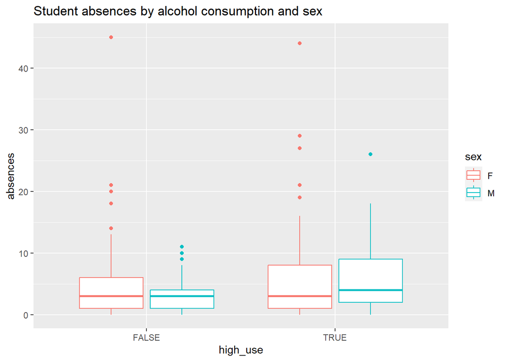

```r
# initialize a plot of high_use and absences
gabs <- ggplot(alc, aes(x = high_use, y = absences))
# define the plot as a box plot and draw it
gabs + geom_boxplot(aes(col=sex)) + ggtitle("Student absences by alcohol consumption and sex")
```

```r
summary(alc$absences)
```

```
##    Min. 1st Qu.  Median    Mean 3rd Qu.    Max.
##   0.000   1.000   3.000   4.511   6.000  45.000
```

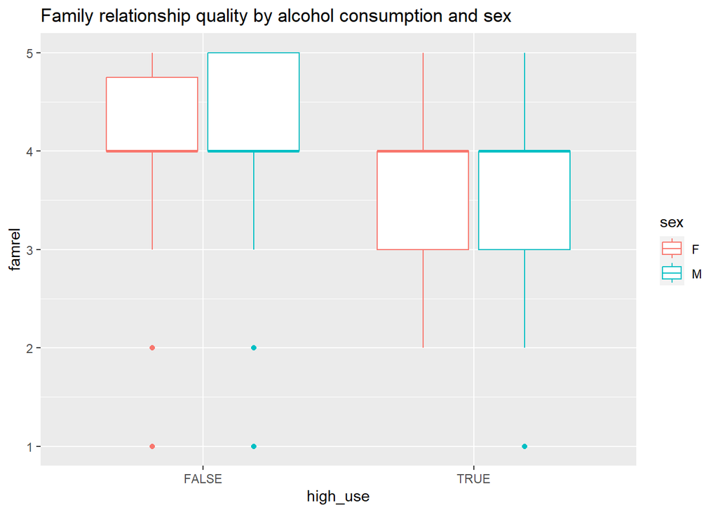

```r
# initialize a plot of high_use and quality of family relationships
gfam <- ggplot(alc, aes(x = high_use, y = famrel))
# define the plot as a box plot and draw it
gfam + geom_boxplot(aes(col=sex)) + ggtitle("Family relationship quality by alcohol consumption and sex")
```

```r
summary(alc$famrel)
```

```
##    Min. 1st Qu.  Median    Mean 3rd Qu.    Max.
##   1.000   4.000   4.000   3.935   5.000   5.000
```

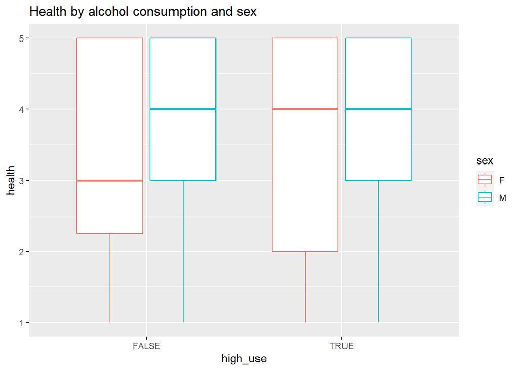

```r
# initialize a plot of high_use and health
ghlth <- ggplot(alc, aes(x = high_use, y = health))
# define the plot as a box plot and draw it
ghlth + geom_boxplot(aes(col=sex)) + ggtitle("Health by alcohol consumption and sex")
```

```r
summary(alc$health)
```

```
##    Min. 1st Qu.  Median    Mean 3rd Qu.    Max.
##   1.000   3.000   4.000   3.562   5.000   5.000
```

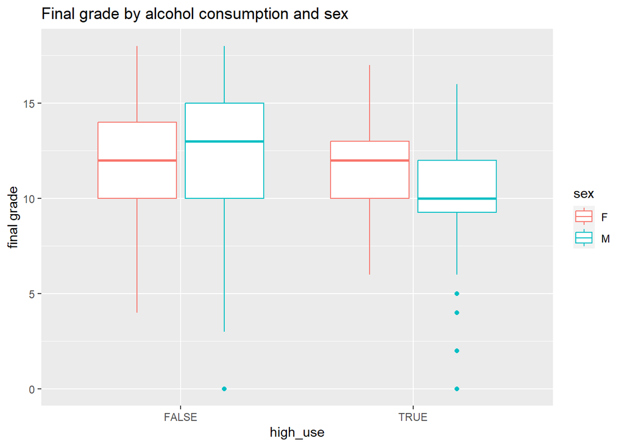

```r
# initialize a plot of high_use and final grade (G3)
gfg <- ggplot(alc, aes(x = high_use, y = G3))
# define the plot as a box plot and draw it
gfg + geom_boxplot(aes(col=sex)) + ylab("final grade") + ggtitle("Final grade by alcohol consumption and sex")
```

```r
summary(alc$G3)
```

```
##    Min. 1st Qu.  Median    Mean 3rd Qu.    Max.
##    0.00   10.00   12.00   11.52   14.00   18.00
```

```r
# tabulate data
dependent <- "high_use"
explanatory <- c("absences", "famrel", "health", "G3")
alc %>%
  summary_factorlist(dependent, explanatory, p = TRUE,
                     add_dependent_label = TRUE)
```

```
##  Dependent: high_use                FALSE       TRUE      p
##             absences Mean (SD)  3.7 (4.5)  6.4 (7.1) <0.001
##               famrel Mean (SD)  4.0 (0.9)  3.8 (0.9)  0.019
##               health Mean (SD)  3.5 (1.4)  3.7 (1.4)  0.134
##                   G3 Mean (SD) 11.8 (3.4) 10.9 (3.0)  0.011
```

Absences seem to increase slightly according to box plot. According to tabulation there is a connection. This supports my hypothesis.

According to both box plot and tabulation, high alcohol usage is connected with poorer family relationships. This is in line with my hypothesis.

For health, for box plot and tabulation show there is no difference. This did not support my hypothesis that health would decrease with high alcohol usage.

Final grade seems to decrease a bit with high alcohol use according to both, box plot and tabulation. This is aligned with my hypothesis.

### Binary logistic regressions

I will start with a model including all four variables (even though it will be unneccary due to tabulation results). After that I will delete variables one by one, checking for AIC in between to see which model to choose and where to stop.

```r
# find the model with glm()
m <- glm(high_use ~ absences + famrel + health + G3, data = alc, family = "binomial")

# print out a summary of the model
summary(m)
```

```
##
## Call:
## glm(formula = high_use ~ absences + famrel + health + G3, family = "binomial",
##     data = alc)
##
## Deviance Residuals:
##     Min       1Q   Median       3Q      Max
## -2.3498  -0.8206  -0.6820   1.1424   1.9666
##
## Coefficients:
##             Estimate Std. Error z value Pr(>|z|)
## (Intercept)  0.12490    0.72091   0.173 0.862450
## absences     0.08193    0.02269   3.612 0.000304 ***
## famrel      -0.27919    0.12753  -2.189 0.028582 *
## health       0.13687    0.08806   1.554 0.120138
## G3          -0.06840    0.03615  -1.892 0.058439 .
## ---
## Signif. codes:  0 '***' 0.001 '**' 0.01 '*' 0.05 '.' 0.1 ' ' 1
##
## (Dispersion parameter for binomial family taken to be 1)
##
##     Null deviance: 452.04  on 369  degrees of freedom
## Residual deviance: 423.36  on 365  degrees of freedom
## AIC: 433.36
##
## Number of Fisher Scoring iterations: 4
```

```r
# print out the coefficients of the model
coef(m)
```

```
## (Intercept)    absences      famrel      health          G3
##  0.12490199  0.08193324 -0.27918935  0.13686832 -0.06840295
```

```r
# compute odds ratios (OR)
OR <- coef(m) %>% exp()
# compute confidence intervals (CI)
CI <- confint(m)
# print out the odds ratios with their confidence intervals
cbind(OR, CI)
```

```
##                    OR       2.5 %       97.5 %
## (Intercept) 1.1330374 -1.29609093  1.539770832
## absences    1.0853833  0.03949360  0.128701401
## famrel      0.7563967 -0.53111331 -0.029290043
## health      1.1466771 -0.03356517  0.312503540
## G3          0.9338841 -0.13975665  0.002411183
```

Let’s remove health from the explaining variables.

```r
# find the model with glm()
m2 <- glm(high_use ~ absences + famrel + G3, data = alc, family = "binomial")

# print out a summary of the model
summary(m2)
```

```
##
## Call:
## glm(formula = high_use ~ absences + famrel + G3, family = "binomial",
##     data = alc)
##
## Deviance Residuals:
##     Min       1Q   Median       3Q      Max
## -2.2678  -0.8248  -0.6893   1.1897   2.0384
##
## Coefficients:
##             Estimate Std. Error z value Pr(>|z|)
## (Intercept)  0.59749    0.65204   0.916 0.359486
## absences     0.08132    0.02276   3.574 0.000352 ***
## famrel      -0.25491    0.12550  -2.031 0.042234 *
## G3          -0.07451    0.03574  -2.085 0.037091 *
## ---
## Signif. codes:  0 '***' 0.001 '**' 0.01 '*' 0.05 '.' 0.1 ' ' 1
##
## (Dispersion parameter for binomial family taken to be 1)
##
##     Null deviance: 452.04  on 369  degrees of freedom
## Residual deviance: 425.82  on 366  degrees of freedom
## AIC: 433.82
##
## Number of Fisher Scoring iterations: 4
```

```r
# print out the coefficients of the model
coef(m2)
```

```
## (Intercept)    absences      famrel          G3
##  0.59749109  0.08131699 -0.25491306 -0.07451065
```

```r
# compute odds ratios (OR)
OR2 <- coef(m2) %>% exp()
# compute confidence intervals (CI)
CI2 <- confint(m2)
# print out the odds ratios with their confidence intervals
cbind(OR2, CI2)
```

```
##                   OR2       2.5 %       97.5 %
## (Intercept) 1.8175530 -0.68389274  1.882796853
## absences    1.0847147  0.03882378  0.128213991
## famrel      0.7749839 -0.50246478 -0.008594584
## G3          0.9281976 -0.14512892 -0.004553643
```

AIC is slightly worse with this model, but as the explaining variables all become significant and it is better to have fewer explanatory variables, I will continue with this model.

Explanatory model confidence intervals do not cross 0, which also indicates they are statistically significant. Just to be sure this model is the best fit, I will test a model without famrel.

```r
# find the model with glm()
m3 <- glm(high_use ~ absences + G3, data = alc, family = "binomial")

# print out a summary of the model
summary(m3)
```

```
##
## Call:
## glm(formula = high_use ~ absences + G3, family = "binomial",
##     data = alc)
##
## Deviance Residuals:
##     Min       1Q   Median       3Q      Max
## -2.3286  -0.8298  -0.7219   1.2113   1.9242
##
## Coefficients:
##             Estimate Std. Error z value Pr(>|z|)
## (Intercept) -0.38732    0.43500  -0.890 0.373259
## absences     0.08423    0.02309   3.648 0.000264 ***
## G3          -0.07606    0.03553  -2.141 0.032311 *
## ---
## Signif. codes:  0 '***' 0.001 '**' 0.01 '*' 0.05 '.' 0.1 ' ' 1
##
## (Dispersion parameter for binomial family taken to be 1)
##
##     Null deviance: 452.04  on 369  degrees of freedom
## Residual deviance: 429.93  on 367  degrees of freedom
## AIC: 435.93
##
## Number of Fisher Scoring iterations: 4
```

```r
# print out the coefficients of the model
coef(m3)
```

```
## (Intercept)    absences          G3
## -0.38731815  0.08422737 -0.07605893
```

```r
# compute odds ratios (OR)
OR3 <- coef(m3) %>% exp()
# compute confidence intervals (CI)
CI3 <- confint(m3)
# print out the odds ratios with their confidence intervals
cbind(OR3, CI3)
```

```
##                   OR3       2.5 %       97.5 %
## (Intercept) 0.6788751 -1.25260555  0.459482521
## absences    1.0878762  0.04110528  0.131708308
## G3          0.9267616 -0.14621889 -0.006471056
```

AIC is higher for this than for the second model. We will continue with the model having absences + famrel + G3 as explanatory variables.

```r
# tabulate data
dependent <- "high_use"
explanatory2 <- c("absences", "famrel", "G3")
alc %>%
  summary_factorlist(dependent, explanatory2, p = TRUE,
                     add_dependent_label = TRUE)
```

```
##  Dependent: high_use                FALSE       TRUE      p
##             absences Mean (SD)  3.7 (4.5)  6.4 (7.1) <0.001
##               famrel Mean (SD)  4.0 (0.9)  3.8 (0.9)  0.019
##                   G3 Mean (SD) 11.8 (3.4) 10.9 (3.0)  0.011
```

In this model, increase in school absences will add the likely hood for high alcohol use. Increase in famrel, that is better family relationships, and in G3 (final grade) will decrease the likely hood for high alcohol use.

### Model predictions

Use the model 2 having absences, famrel, and G3 as predictors.

```r
# predict() the probability of high_use
probabilities <- predict(m2, type = "response")

# add the predicted probabilities to 'alc'
alc <- mutate(alc, probability = probabilities)
# use the probabilities to make a prediction of high_use
alc <- mutate(alc, prediction = high_use)
# see the last ten original classes, predicted probabilities, and class predictions
select(alc, failures, absences, sex, high_use, probability, prediction) %>% tail(10)
```

```
##     failures absences sex high_use probability prediction
## 361        0        3   M    FALSE   0.2410652      FALSE
## 362        1        0   M    FALSE   0.3959997      FALSE
## 363        1        7   M     TRUE   0.4361317       TRUE
## 364        0        1   F    FALSE   0.1839390      FALSE
## 365        0        6   F    FALSE   0.3704366      FALSE
## 366        1        2   F    FALSE   0.2917307      FALSE
## 367        0        2   F    FALSE   0.2398221      FALSE
## 368        0        3   F    FALSE   0.5716255      FALSE
## 369        0        4   M     TRUE   0.3645417       TRUE
## 370        0        2   M     TRUE   0.2680314       TRUE
```

```r
# tabulate the target variable versus the predictions
table(high_use = alc$high_use, prediction = alc$prediction)
```

```
##         prediction
## high_use FALSE TRUE
##    FALSE   259    0
##    TRUE      0  111
```

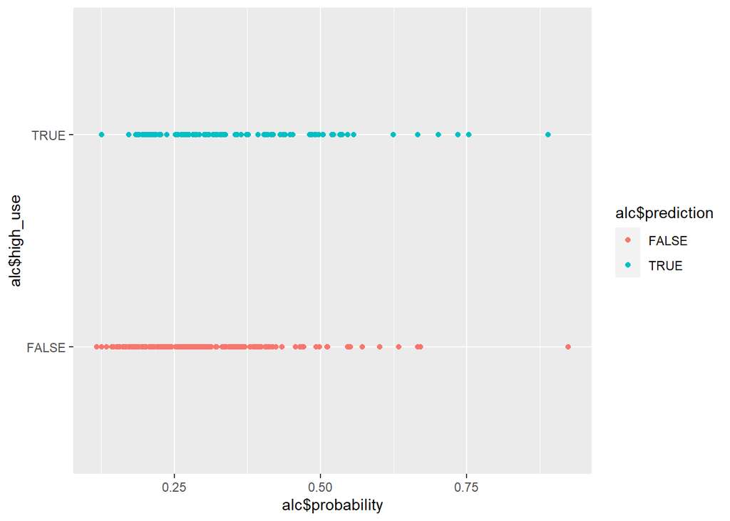

```r
# initialize a plot of 'high_use' versus 'probability' in 'alc'
g <- ggplot(alc, aes(x = alc$probability, y = alc$high_use))
# define the geom as points and draw the plot
g + geom_point(aes(col = alc$prediction))
```

```r
# tabulate the target variable versus the predictions
table(high_use = alc$high_use, prediction = alc$prediction) %>% prop.table() %>% addmargins()
```

```
##         prediction
## high_use FALSE TRUE Sum
##    FALSE   0.7  0.0 0.7
##    TRUE    0.0  0.3 0.3
##    Sum     0.7  0.3 1.0
```

```r
# define a loss function (mean prediction error)
loss_func <- function(class, prob) {
  n_wrong <- abs(class - prob) > 0.5
  mean(n_wrong)
}
# call loss_func to compute the average number of wrong predictions in the (training) data
loss_func(class = alc$probability, prob = 0)
```

```
## [1] 0.07567568
```